# Estudios de Informática, Multimedia y Telecomunicaciones

```r
summary(retraso_glm2)
```

```
##
## Call:
## glm(formula = RETRASO ~ DEPARTURE_HOUR + DISTANCE, family = binomial(logit),
##     data = retraso2)
##
## Deviance Residuals:
##     Min       1Q   Median       3Q      Max
## -0.8554  -0.8013  -0.7740   1.5698   1.9131
##
## Coefficients:
##                    Estimate Std. Error z value Pr(>|z|)
## (Intercept)      -1.138e+00  7.046e-02 -16.148  < 2e-16 ***
## DEPARTURE_HOUR 1  2.647e-01  1.252e-01   2.114 0.034503 *
## DEPARTURE_HOUR 2  8.046e-02  2.293e-01   0.351 0.725642
## DEPARTURE_HOUR 3 -2.352e-02  3.623e-01  -0.065 0.948239
## DEPARTURE_HOUR 4  1.639e-01  1.249e-01   1.312 0.189576
## DEPARTURE_HOUR 5  1.329e-01  7.371e-02   1.803 0.071430 .
## DEPARTURE_HOUR 6  2.918e-01  7.177e-02   4.066 4.78e-05 ***
## DEPARTURE_HOUR 7  3.304e-01  7.181e-02   4.601 4.20e-06 ***
## DEPARTURE_HOUR 8  2.720e-01  7.183e-02   3.786 0.000153 ***
## DEPARTURE_HOUR 9  2.674e-01  7.193e-02   3.718 0.000201 ***
## DEPARTURE_HOUR10  2.657e-01  7.183e-02   3.699 0.000217 ***
## DEPARTURE_HOUR11  2.291e-01  7.193e-02   3.186 0.001445 **
## DEPARTURE_HOUR12  1.948e-01  7.198e-02   2.707 0.006799 **
## DEPARTURE_HOUR13  2.294e-01  7.197e-02   3.187 0.001435 **
## DEPARTURE_HOUR14  2.068e-01  7.208e-02   2.869 0.004124 **
## DEPARTURE_HOUR15  2.056e-01  7.194e-02   2.857 0.004270 **
## DEPARTURE_HOUR16  2.370e-01  7.205e-02   3.290 0.001003 **
## DEPARTURE_HOUR17  2.739e-01  7.181e-02   3.815 0.000136 ***
## DEPARTURE_HOUR18  2.889e-01  7.206e-02   4.010 6.07e-05 ***
## DEPARTURE_HOUR19  2.173e-01  7.208e-02   3.015 0.002570 **
## DEPARTURE_HOUR20  1.849e-01  7.261e-02   2.547 0.010867 *
## DEPARTURE_HOUR21  1.172e-01  7.368e-02   1.591 0.111627
## DEPARTURE_HOUR22  1.638e-01  7.542e-02   2.171 0.029902 *
## DEPARTURE_HOUR23  8.998e-02  8.307e-02   1.083 0.278685
## DEPARTURE_HOUR24  2.061e-01  5.215e-01   0.395 0.692714
## DISTANCE         -1.415e-04  7.266e-06 -19.476  < 2e-16 ***
## ---
## Signif. codes:  0 '***' 0.001 '**' 0.01 '*' 0.05 '.' 0.1 ' ' 1
##
## (Dispersion parameter for binomial family taken to be 1)
##
##     Null deviance: 330629  on 285649  degrees of freedom
## Residual deviance: 330070  on 285624  degrees of freedom
## AIC: 330122
##
## Number of Fisher Scoring iterations: 4
```

```r
retraso3 <- data.frame(retraso2, MONTH=vuelos_reduc$MONTH,
                      SCHEDULED_DEPARTURE=vuelos_reduc$SCHEDULED_DEPARTURE)
str(retraso3)
```

```
## 'data.frame':    285650 obs. of  6 variables:
##  $ RETRASO            : Factor w/ 2 levels "NO","SI": 2 1 1 1 1 1 2 1 1 2 ...
##  $ WEEKEND            : Factor w/ 2 levels "WEEKDAY","WEEKEND": 1 1 1 1 1 1 1 2 2 2 ...
##  $ DEPARTURE_HOUR     : Factor w/ 25 levels " 0"," 1"," 2",..: 9 10 6 16 12 6 12 21 13 20 ...
##  $ DISTANCE           : int  674 1407 153 468 1363 184 439 216 268 680 ...
##  $ MONTH              : int  11 4 4 7 2 7 12 2 3 2 ...
##  $ SCHEDULED_DEPARTURE: int  825 930 540 1545 1055 600 1125 1956 1145 1935 ...
```

```r
retraso_glm3 <- glm(RETRASO~SCHEDULED_DEPARTURE + DISTANCE + MONTH, data=retraso3, family=binomial)
retraso_glm3
```

```
##
## Call:  glm(formula = RETRASO ~ SCHEDULED_DEPARTURE + DISTANCE + MONTH,
##     family = binomial, data = retraso3)
##
## Coefficients:
##         (Intercept)  SCHEDULED_DEPARTURE             DISTANCE
##          -6.240e-01           -5.973e-05           -1.406e-04
##               MONTH
##          -3.098e-02
##
## Degrees of Freedom: 285649 Total (i.e. Null);  285646 Residual
## Null Deviance:       330600
## Residual Deviance: 329600    AIC: 329600
```

```r
summary(retraso_glm3)
```

```
##
## Call:
## glm(formula = RETRASO ~ SCHEDULED_DEPARTURE + DISTANCE + MONTH,
##     family = binomial, data = retraso3)
##
## Deviance Residuals:
##     Min       1Q   Median       3Q      Max
## -0.9072  -0.8047  -0.7607   1.5312   1.9557
##
## Coefficients:
##                       Estimate Std. Error z value Pr(>|z|)
## (Intercept)         -6.240e-01  1.583e-02 -39.408  < 2e-16 ***
## SCHEDULED_DEPARTURE -5.973e-05  8.804e-06  -6.785 1.16e-11 ***
## DISTANCE            -1.406e-04  7.205e-06 -19.519  < 2e-16 ***
## MONTH               -3.098e-02  1.250e-03 -24.786  < 2e-16 ***
## ---
## Signif. codes:  0 '***' 0.001 '**' 0.01 '*' 0.05 '.' 0.1 ' ' 1
##
## (Dispersion parameter for binomial family taken to be 1)
##
##     Null deviance: 330629  on 285649  degrees of freedom
## Residual deviance: 329571  on 285646  degrees of freedom
## AIC: 329579
##
## Number of Fisher Scoring iterations: 4
```

```r
#Realizamos una predicción de retraso con nuestro modelo, en el caso de un vuelo que salga a las 16horas y
#con una distancia de 1000 milas en el mes de junio
newdata = data.frame(SCHEDULED_DEPARTURE = 0800 , DISTANCE=1000, MONTH=6)
predict(retraso_glm3, newdata , type="response")
```

```
##         1
## 0.2692799
```

```r
newdata2 = data.frame(SCHEDULED_DEPARTURE =1600, DISTANCE=1000, MONTH=6)
predict(retraso_glm3, newdata2 , type="response")
```

```
##         1
## 0.2599812
```

```r
#Incluimos la variables aeropuerto.
retraso4 <- data.frame(retraso3, ORIGIN_AIRPORT=vuelos_reduc$ORIGIN_CODE)
```

```r
# Para que los resultados estén acotados, elegimos los 10 aeropuertos con más tráfico:
retraso$ORIGIN_AIRPORT <- ifelse (retraso4$ORIGIN_AIRPORT %in%
                            c("ATL","ORD","DFW","DEN","LAX","SFO","PHX","IAH","LAS","MSP"),
                            retraso4$ORIGIN_AIRPORT,
                            "OTROS")
str(retraso3)
```

```
## 'data.frame':    285650 obs. of  6 variables:
##  $ RETRASO            : Factor w/ 2 levels "NO","SI": 2 1 1 1 1 1 2 1 1 2 ...
##  $ WEEKEND            : Factor w/ 2 levels "WEEKDAY","WEEKEND": 1 1 1 1 1 1 1 2 2 2 ...
##  $ DEPARTURE_HOUR     : Factor w/ 25 levels " 0"," 1"," 2",..: 9 10 6 16 12 6 12 21 13 20 ...
##  $ DISTANCE           : int  674 1407 153 468 1363 184 439 216 268 680 ...
##  $ MONTH              : int  11 4 4 7 2 7 12 2 3 2 ...
##  $ SCHEDULED_DEPARTURE: int  825 930 540 1545 1055 600 1125 1956 1145 1935 ...
```

```r
#retraso_glm4 <- glm(RETRASO~DEPARTURE_HOUR + DISTANCE + MONTH + ORIGIN_AIRPORT, data=retraso4,
#                    family=binomial)
#retraso_glm4
#summary(retraso_glm4)
```

Vamos a realizar un contraste de hipótesis, nos preguntamos si la proporción de vuelos retrasados es inferior a la de vuelos en los tiempos establecidos.Para ello realizaremos un contraste sobre la proporción para muestras grandes.
Consideramos que tenemos una población que toma el valor 1 cuando el vuelo está retrasado y el 0 cuando no lo está. Tenemos por tanto una distribución de Bernoulli con parámetro *p* desconocido. $p_0$ será un valor prefijado, en nuestro caso 0.5, es decir el 50% que marcaría la igualdad de proporción de vuelos retrasados y no retrasados.
$$\left\{
\begin{array}{ll}
Hipótesis\ Nula & H_{0}: & p = p_0\\
Hipótesis\ Alternativa & H_{1}: & p < p_0
\end{array}
\right.$$

Separamos las muestras de los vuelos retrasados RETRASO_TOTAL>0 y los no retrasados RETRASO_TOTAL<=0

```r
head(vuelos_reduc)
```

```
##   MONTH DAY DAY_OF_WEEK AIRLINE FLIGHT_NUMBER ORIGIN_CODE DESTINATION_AIRPORT
## 1    11  16           1      EV          5084         ATL                 TUL
## 2     4   7           2      WN          1023         BWI                 SAT
## 3     4   1           3      DL          2182         GSP                 ATL
## 4     7  28           2      EV          4330         MEM                 IAH
## 5     2   9           1      WN          1963         LAX                 MCI
## 6     7  23           4      AA          2148         BOS                 LGA
##   SCHEDULED_DEPARTURE DEPARTURE_TIME DEPARTURE_DELAY SCHEDULED_TIME
## 1                 825            819              -6            128
## 2                 930            943              13            240
## 3                 540            538              -2             57
## 4                1545           1559              14            108
## 5                1055           1105              10            190
## 6                 600            553              -7             74
##   ELAPSED_TIME AIR_TIME DISTANCE SCHEDULED_ARRIVAL ARRIVAL_TIME ARRIVAL_DELAY
## 1          129      111      674               933          928            -5
## 2          214      201     1407              1230         1217           -13
## 3           47       28      153               637          625           -12
## 4          105       75      468              1733         1744            11
## 5          166      153     1363              1605         1551           -14
## 6           68       47      184               714          701           -13
##   SCHEDULED_DEPARTURE_HOUR DEPARTURE_HOUR ARRIVAL_HOUR RETRASO_TOTAL
## 1                        8              8            9             1
## 2                        9              9           12           -26
## 3                        5              5            6           -10
## 4                       15             15           17            -3
## 5                       10             11           15           -24
## 6                        6              5            7            -6
```

```r
vuelos_reduc$DELAYED <- ifelse(vuelos_reduc$RETRASO_TOTAL>0, 1, 0)

vuelos_reduc %>%
  group_by(DELAYED) %>%
  summarize(num_obs = n(),
            mean_delayed = round(mean(RETRASO_TOTAL),0),
            sd_delayed = round(sd(RETRASO_TOTAL),0))
```

```
## # A tibble: 2 x 4
##   DELAYED num_obs mean_delayed sd_delayed
##     <dbl>   <int>        <dbl>      <dbl>
## 1       0  209810          -10          8
## 2       1   75840           10         12
```

```r
DELAYED_GROUPED <- vuelos_reduc %>% group_by(DELAYED) %>% summarize(num_obs = n(),
                                                                    obs_totales =length(vuelos_reduc$DAY),
                                                                    p = num_obs/obs_totales)
DELAYED_GROUPED %>% knitr::kable("html")  %>% kable_styling(position='center', font_size=12, fixed_thead=list(enabled=T))
```

| DELAYED | num_obs | obs_totales | p |
| --- | --- | --- | --- |
| 0 | 209810 | 285650 | 0.7345003 |
| 1 | 75840 | 285650 | 0.2654997 |

```r
n1=DELAYED_GROUPED[1,2]
n2=DELAYED_GROUPED[2,2]

prop.test(x=c(209810,75840), n=c(285650,285650), p=NULL, alternative="less", correct=TRUE)
```

```
##
##  2-sample test for equality of proportions with continuity correction
##
## data:  c(209810, 75840) out of c(285650, 285650)
## X-squared = 125662, df = 1, p-value = 1
## alternative hypothesis: less
## 95 percent confidence interval:
##  -1.000000  0.470926
## sample estimates:
##    prop 1    prop 2
## 0.7345003 0.2654997
```

# **5. Representación de los resultados**

**Representación de los resultados a partir de tablas y gráficas.**

En este apartado intentaremos dar respuesta a algunas de nuestras dudas mediante la representación gráfica de los datos elegidos.  
Comenzamos las representaciones viendo qué aeropuertos son los que mayor volumen de vuelos acogen:

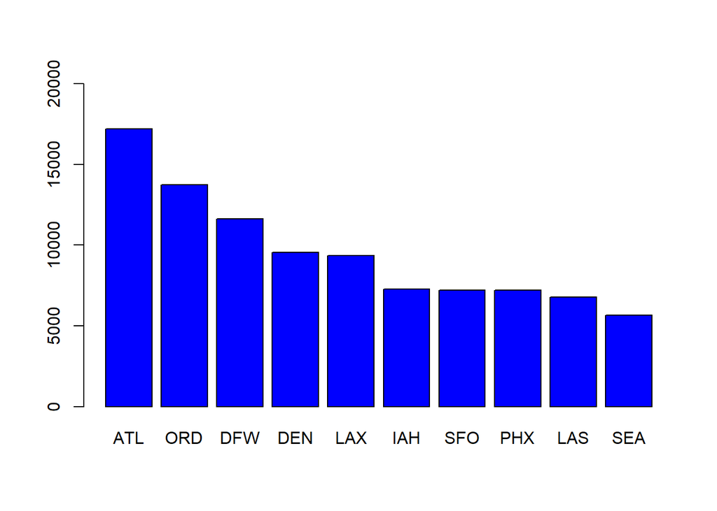

```r
#Comprobamos en un gráfico de barras los aeropuertos más populares.
popular_airports <- sort(table(vuelos_reduc$ORIGIN_CODE), decreasing = TRUE )
barplot(popular_airports[1:10], col = "blue", ylim = c(0,20000))
```

En la gráfica de barras podemos observar que fue el aeropuerto de Atlanta el más popular de Estados Unidos en el año 2015. En realidad, era de esperar este resultado, dado que el aeropuerto de Atlanta es el aeropuerto con más tráfico aéreo de Estados Unidos y del mundo.

Una vez que tenemos el aeropuerto, ahora vamos a ver qué dia de la semana es en el que se producen más vuelos.

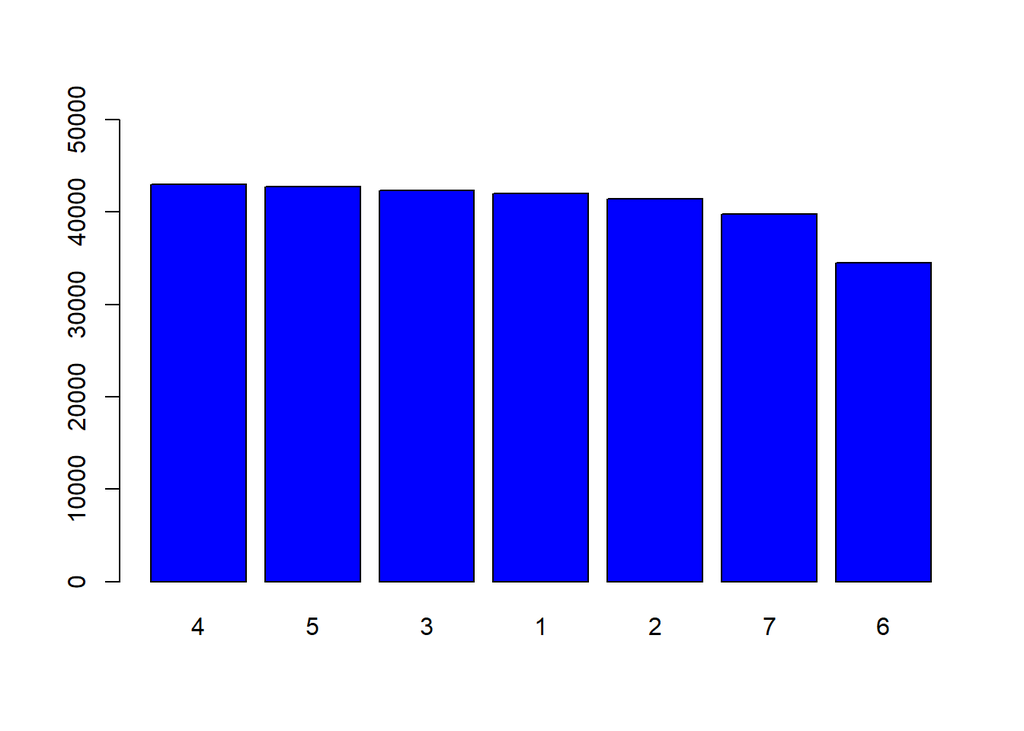

```r
#visualización del volumen de vuelos de cada día de la semana

dias_semana <- sort(table(vuelos_reduc$DAY_OF_WEEK), decreasing=TRUE)


barplot(dias_semana, col = "blue", ylim = c(0,50000))
```

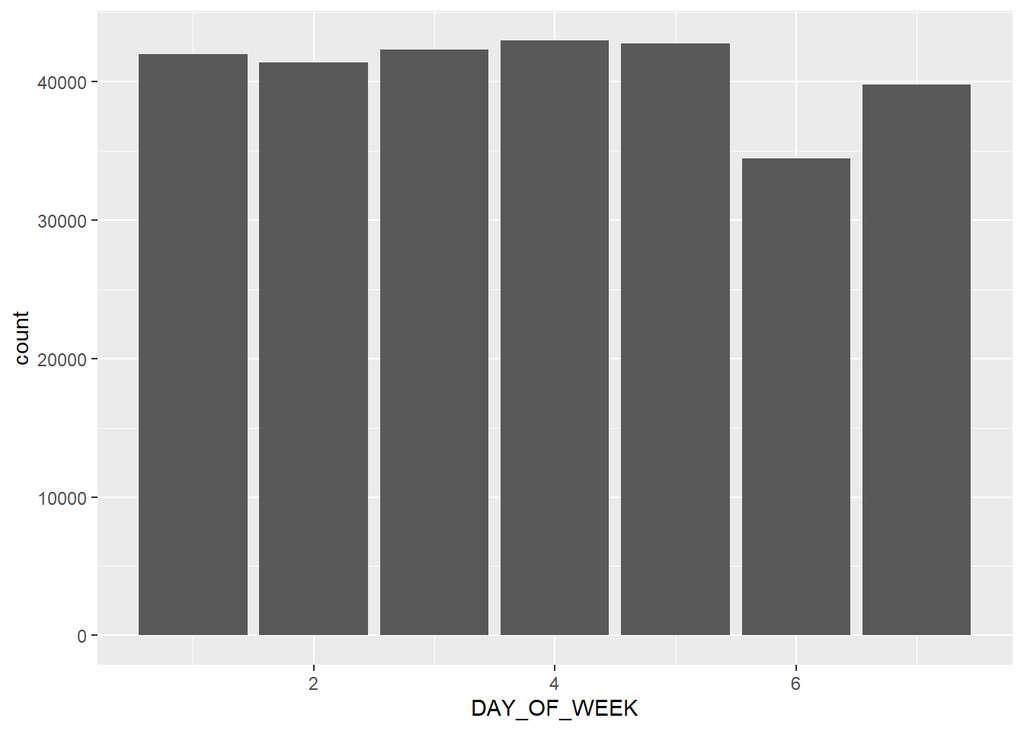

```r
ggplot(vuelos_reduc, aes(x=DAY_OF_WEEK, fill=DAY_OF_WEEK )) +
  geom_bar( ) +
  scale_fill_hue(c = 40)
```

Se comprueba que el tráfico diario en los días laborables es muy similar, viendose un cambio de tendencia en el fin de semana, en concreto en el sábado.

En el siguiente gráfico, veremos la relación del número de vuelos frente al mes del año:

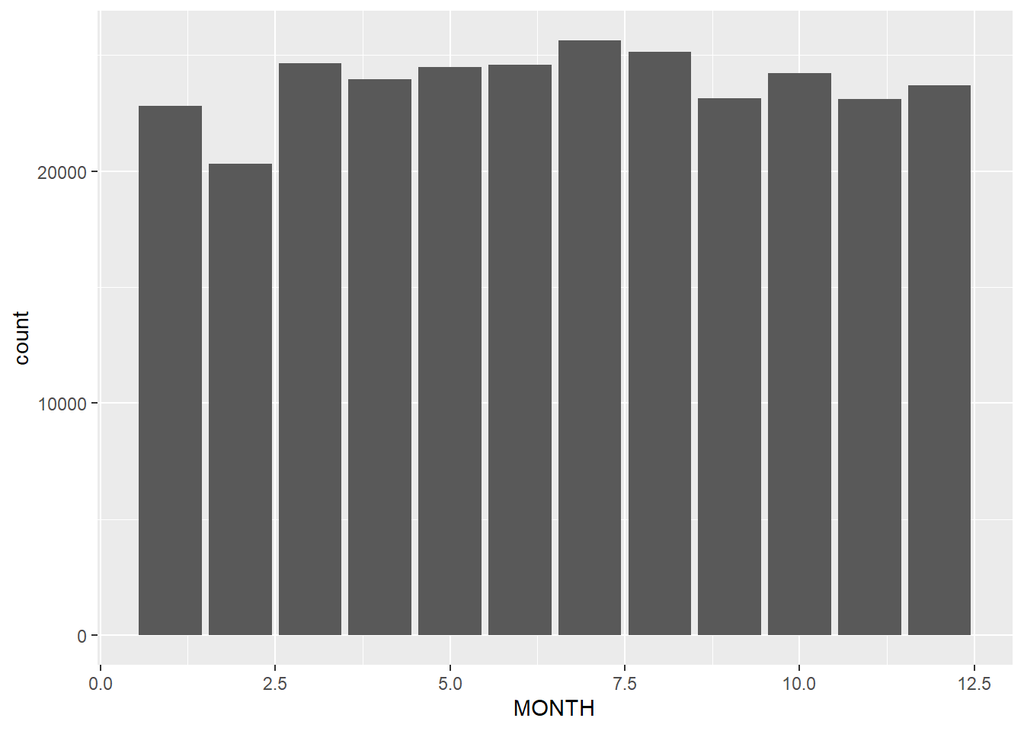

```r
ggplot(vuelos_reduc, aes(x=MONTH, fill=MONTH )) +
  geom_bar( ) +
  scale_fill_hue(c = 20)
```

De este gráfico comprobamos que febrero es el mes que menos vuelos se producen (uno de los factores que pueden influir en este hecho es que es el mes del año más corto).  
Por otro lado vemos, que los meses de verano son los que mayor afluencia de vuelos hay, siendo julio el que alberga el mayor número de vuelos.

Otra conclusión que podemos sacar, es que quitando los meses de verano, en el resto del año se aprecia la tencencia en el que los meses con 30 días tienen menor volumen de vuelos que los de 31 días.

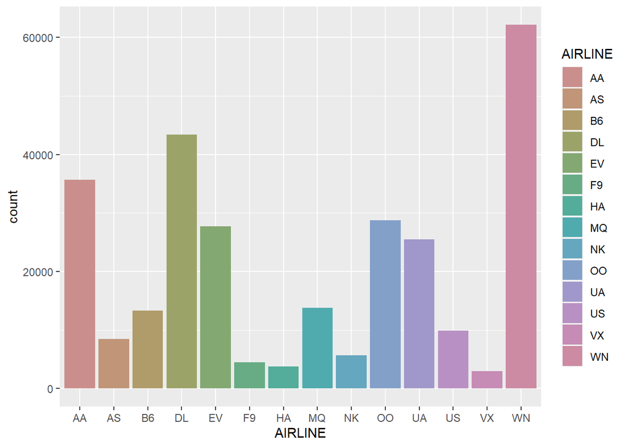

```r
ggplot(vuelos_reduc, aes(x=AIRLINE, fill=AIRLINE )) +
  geom_bar( ) +
  scale_fill_hue(c = 40)
```

En el grafico que muestran el número de vuelos de cada aerolínea podemos ver como una de ellas prevalece sobre todas las demás.  
La aerolínea WN, cuyas siglas corresponden a Southwest Airlines Co. operó más de 60000 vuelos en el año 2015 en Estados Unidos, mientras que la segunda que le sigue en el ranking operó 45000 vuelos. Vemos que la diferencia es muy significativa. Southwest Airlines es la mayor compañía aeronáutica de Estados Unidos y el mayor operador de bajo coste del mundo.

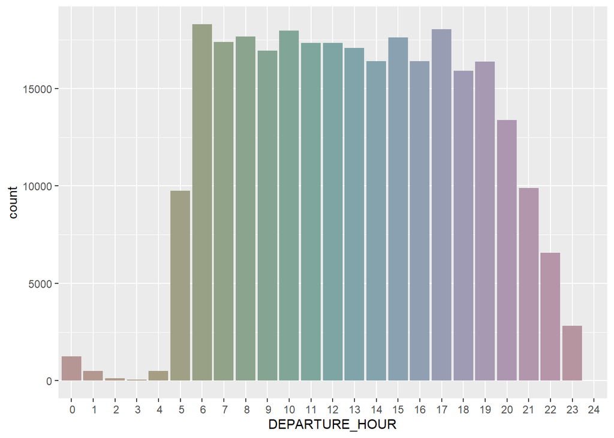

```r
#Horas de salida de los vuelos
ggplot(vuelos_reduc, aes(x=DEPARTURE_HOUR, fill=DEPARTURE_HOUR )) +
  geom_bar( ) +
  scale_fill_hue(c = 20) +
  theme(legend.position="none")
```

También queremos comprobar las horas del día con mayor número de vuelos y, como era de esperar la mayoría de los vuelos se producen de 6 de la mañana a 7 de la tarde. Cayendo significativamente a valores prácticamente nulos en la madrugada.

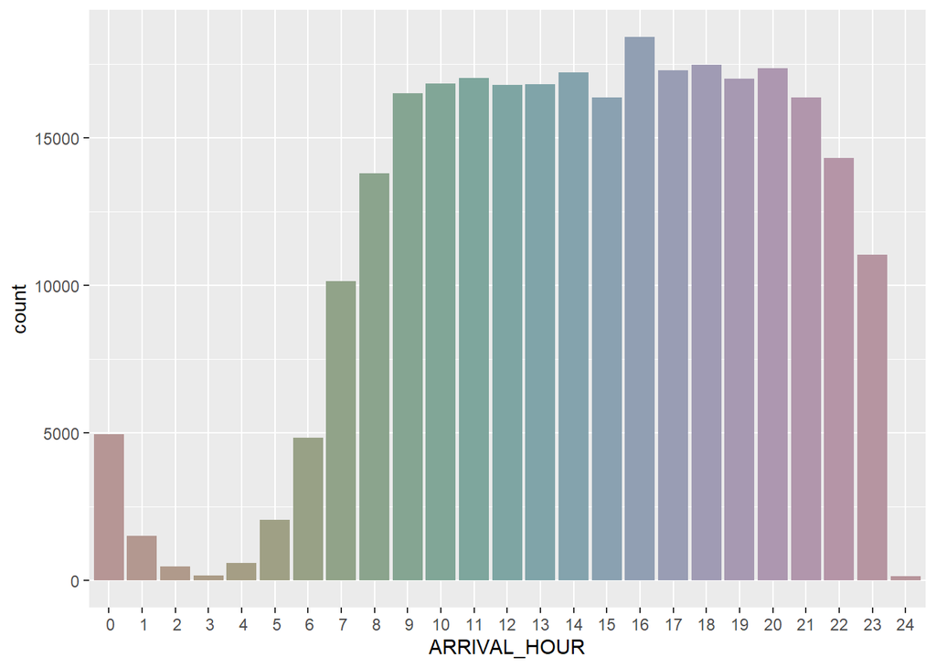

```r
#Horas de llegada
ggplot(vuelos_reduc, aes(x=ARRIVAL_HOUR, fill=ARRIVAL_HOUR )) +
  geom_bar( ) +
  scale_fill_hue(c = 20) +
  theme(legend.position="none")
```

Por otro lado, las horas de llegadas más populares fueron de 9 de la mañana a 9 de la noche. Vemos que hay un desplazamiento de horario de 2-3 horas con respecto a la gráfica de las horas de salida, lo cual es lógico si tenemos en cuenta la duración de los vuelos.

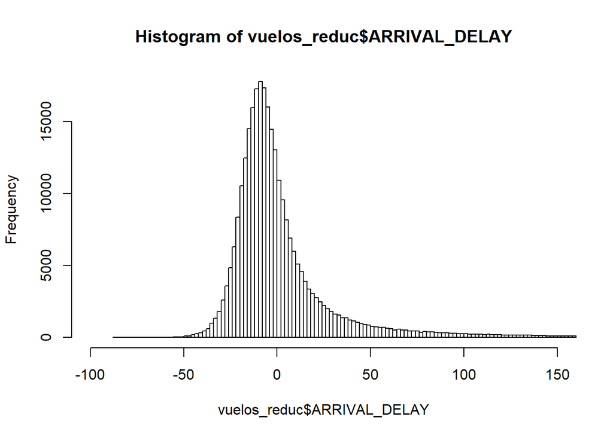

```r
hist(vuelos_reduc$ARRIVAL_DELAY,breaks = 1000, xlim = c(-100,150))
```

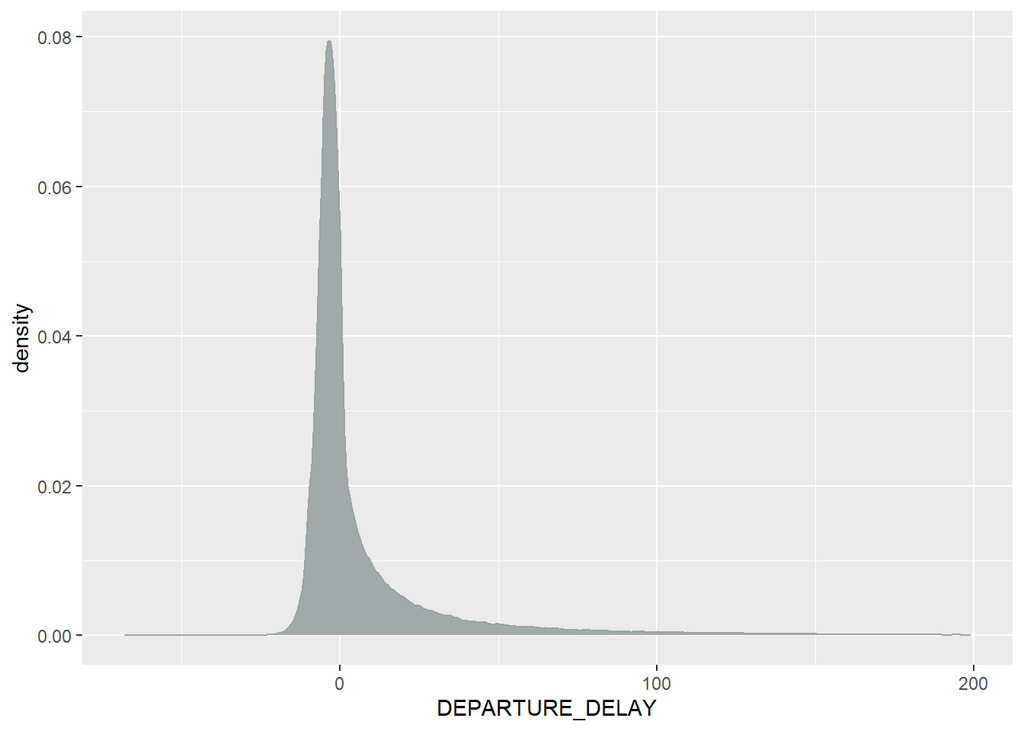

```r
#Retraso por aerolínea
#Analizamos los vuelos retrasados cuando el retraso es menor de 200 minutos
vuelos_reduc %>%
  filter( DEPARTURE_DELAY<200) %>%
  ggplot( aes(x=DEPARTURE_DELAY)) +
  geom_density(fill="#99A3A4", color="#99A3A4", alpha=0.9)
```

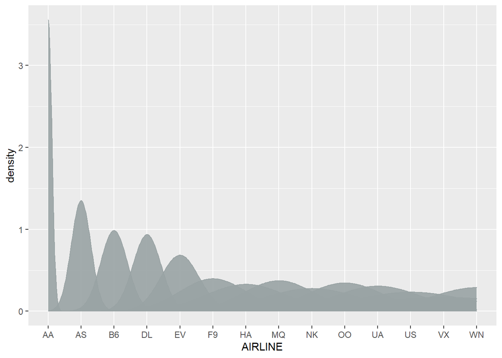

```r
vuelos_reduc %>%
  filter( ARRIVAL_DELAY<200) %>%
  ggplot( aes(x=AIRLINE)) +
  geom_density(fill="#99A3A4", color="#99A3A4", alpha=0.9)
```

# **6. Resolución del problema**

# **7. Código**

**Adjuntar el código con el que se ha realizado la limpieza, análisis y representación de los datos.**

# **8. Contribuciones al trabajo**

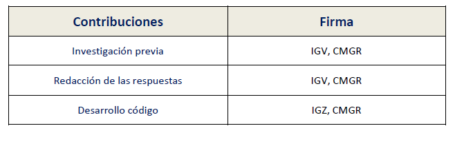

# Referencias:

https://rpubs.com  
https://www.kaggle.com/usdot/flight-delays